# Fit Funk?

Francisco Igor de Lima Mendes

15/03/2020

## Usaremos uma amostra de dados de playlists do spotify com o objetivo de aplicar alguns conceitos básicos de EDA.

Dada essas playlist e suas músicas estamos interessados em investigar qual seria a melhor para usar em uma seção de Fit Dance.

Dito isso, usaremos os indices de energia e dançabilidade de cada música para podermos traçar qual playlist daria a maior e, possivelmente, a melhor disposição para tal atividade.

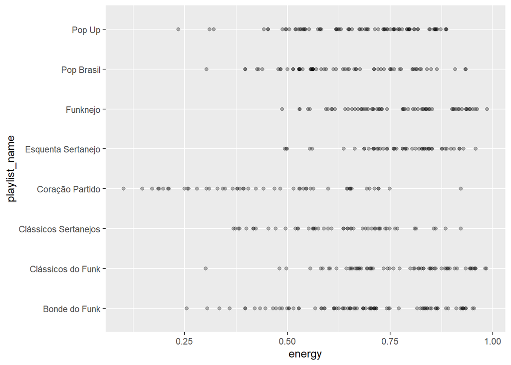

```r
#Pontos playlists mais energeticas
spotify %>%
group_by(playlist_name) %>%
ggplot(mapping=aes(x=energy,y=playlist_name))+
geom_point(alpha = 0.3)
```

Playlists de Funk tendem a serem mais energéticas, atingindo, em algumas músicas quase o máximo do índice. Isso nos leva a concluir que as músicas de Funk, provavelmente, são as mais eletrizantes, barulhentas e rápidas.

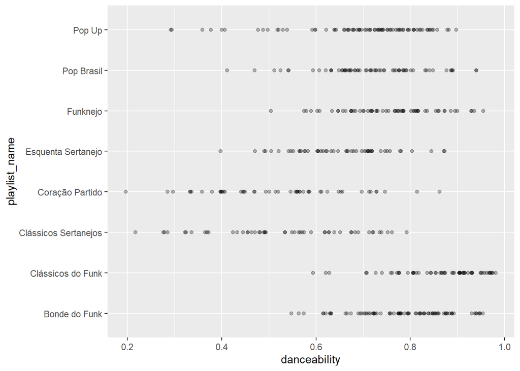

```r
#Pontos playlists mais dançáveis
spotify %>%
group_by(playlist_name) %>%
ggplot(mapping=aes(y=playlist_name,x=danceability))+
geom_point(alpha = 0.3)
```

A playlist “Clássicos do Funk”, com uma das músicas mais energéticas, também mostra ser uma playlist incrívelmente dançável, pois boa parte das músicas dela tem o índice de dançabilidade entre 0.8 e ~0.97.

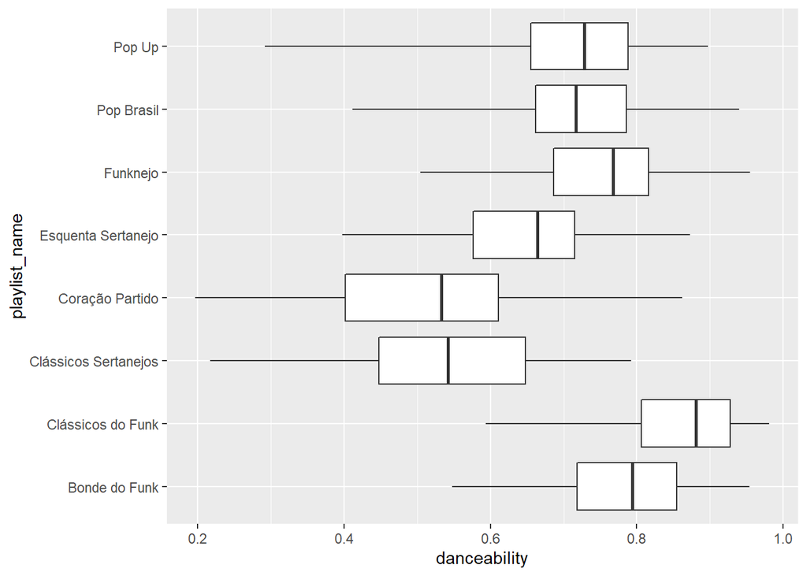

```r
#Boxplot playlists mais dançáveis
spotify %>%
group_by(playlist_name) %>%
ggplot(mapping=aes(y=playlist_name,x=danceability))+
geom_boxplot(coef = 1000)
```

O Boxplot agora mostra que Clássicos do Funk tem a maioria dos seus pontos entre 0.81 e 0.93. Assim, sendo a playlist de maior dançabilidade.

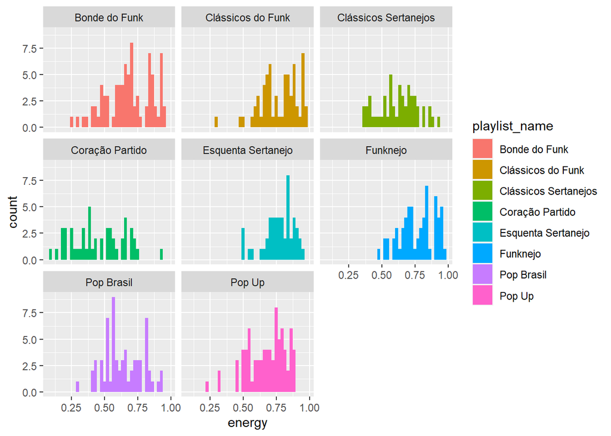

```r
#Histogramas dos indices dançabilidade e energia das playlists

spotify %>%
group_by(playlist_name) %>%
ggplot()+
geom_histogram(mapping=aes(x = energy,fill = playlist_name),bins = 40)+
facet_wrap(spotify$playlist_name)
```

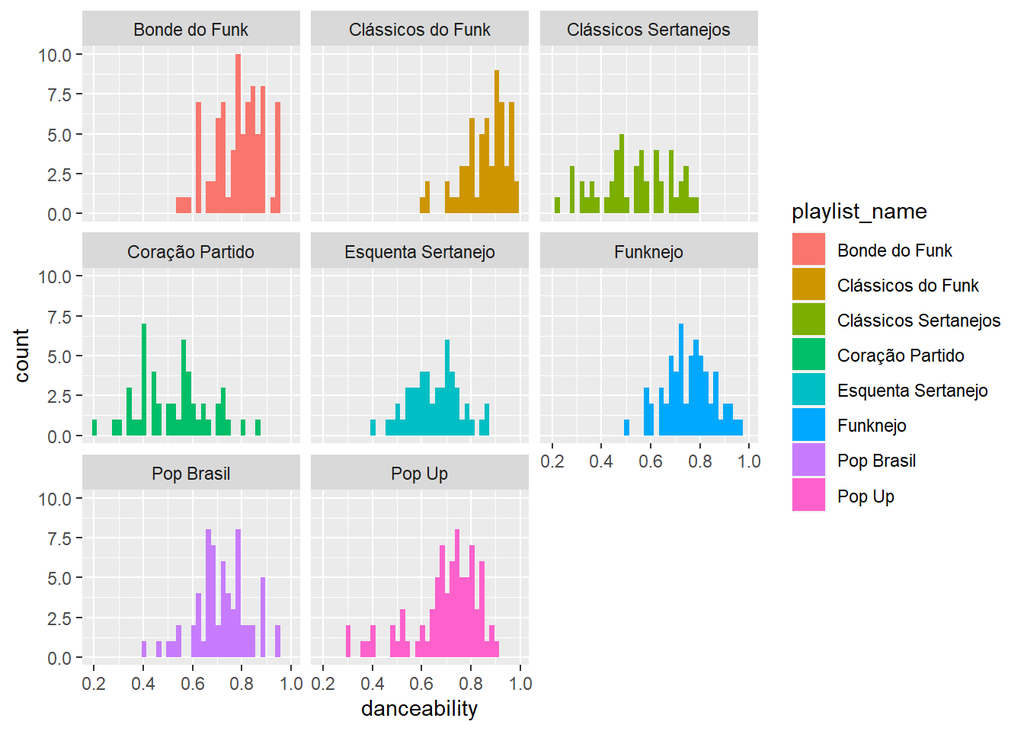

```r
spotify %>%
group_by(playlist_name) %>%
ggplot()+
geom_histogram(mapping=aes(x = danceability,fill = playlist_name),bins = 40)+
facet_wrap(spotify$playlist_name)
```

O primeiro histograma mostra que, aparentemente, “Clássicos do Funk”, “Bonde do Funk” e “Funknejo” tem mais músicas com energia próximas ao máximo. Apesar disso, a dançabilidade da “Clássico do Funk” supera todas as outras playlists, como foi visto em vizualizações anteriores.

```r
#Summário das médias de dançabilidade para cada playlist

sumario = spotify %>%
group_by(playlist_name) %>%
summarise(dancabilidade_media = mean(danceability),qtd_musicas = n(),max_danca=max(danceability), min_danca=min(danceability))

sumario %>% arrange(desc(dancabilidade_media))
```

```
## # A tibble: 8 x 5
##   playlist_name        dancabilidade_media qtd_musicas max_danca min_danca
##   <fct>                              <dbl>       <int>     <dbl>     <dbl>
## 1 Clássicos do Funk                  0.860          62     0.981     0.594
## 2 Bonde do Funk                      0.784          83     0.954     0.548
## 3 Funknejo                           0.756          62     0.955     0.504
## 4 Pop Brasil                         0.719          64     0.94      0.412
## 5 Pop Up                             0.695          80     0.897     0.292
## 6 Esquenta Sertanejo                 0.652          51     0.873     0.398
## 7 Clássicos Sertanejos               0.534          50     0.792     0.217
## 8 Coração Partido                    0.522          50     0.862     0.197
```

```r
#Summário das médias de energia para cada playlist

sumario = spotify %>%
group_by(playlist_name) %>%
summarise(energia_media = mean(energy),qtd_musicas = n(),max_energia=max(energy), min_energia=min(energy))

sumario %>% arrange(desc(energia_media))
```

```
## # A tibble: 8 x 5
##   playlist_name        energia_media qtd_musicas max_energia min_energia
##   <fct>                        <dbl>       <int>       <dbl>       <dbl>
## 1 Esquenta Sertanejo           0.772          51       0.958       0.494
## 2 Clássicos do Funk            0.771          62       0.984       0.301
## 3 Funknejo                     0.770          62       0.986       0.487
## 4 Bonde do Funk                0.682          83       0.954       0.255
## 5 Pop Up                       0.677          80       0.887       0.235
## 6 Pop Brasil                   0.641          64       0.934       0.303
## 7 Clássicos Sertanejos         0.623          50       0.922       0.369
## 8 Coração Partido              0.453          50       0.922       0.102
```

Por “Clássicos do Funk” ter o melhor “centro de massa” da dançabilidade, a segunda melhor energia e levando em conta as outras vizualizações das variáveis escolhidas, ela provavelmente seria a melhor playlist para uma seção de Fit Dance.